# Hands on Ordinal Logistic Regression

## By Johannes Simatupang M.Kom.,COBIT5 (Feb 2026)

### COMP6577 - Machine Learning >>> Bina Nusantara University

Description: Logistic regression is one of the most popular Machine Learning algorithms, which comes under the Supervised Learning technique. Logistic regression predicts the output of a categorical dependent variable. Logistic regression is used for solving the classification problems.

Type of Logistic Regression:

1. Binomial: In binomial Logistic regression, there can be only two possible types of the dependent variables, such as 0 or 1, Pass or Fail, etc.
2. Multinomial: In multinomial Logistic regression, there can be 3 or more possible unordered types of the dependent variable, such as "cat", "dogs", or "sheep"
3. Ordinal: In ordinal Logistic regression, there can be 3 or more possible ordered types of dependent variables, such as "low", "Medium", or "High".

We can categorize the ordinal regression into two categories:

1. Ordered logit model: We can also call this model an ordered logistic model that works for ordinal dependent variables and a pure regression model. For example, we have reviews of any questionnaire about any product as bad, good, nice, and excellent on a survey and we want to analyze how well these responses can be predicted for the next product. If questions are quantitative then we can use this model. We can think of it as an extension of logistic regression that allows more than two response categories that are in an ordered way.
2. Ordered probit model: We can consider this model as a variant of the probit model, it is with an ordinal dependent variable where we can have more than two outcomes. An ordinal dependent variable can be defined as a variable in which the values have a natural ordering, for example bad, good, nice, excellent.

```python
#Importing the libraries
import pandas as pd
```

```python
#load dataset
data_diam = pd.read_csv('diamonds.csv')
data_diam.head(10)
```

|  | carat | cut | color | clarity | depth | table | x | y | z | price |
| --- | --- | --- | --- | --- | --- | --- | --- | --- | --- | --- |
| 0 | 0.23 | Ideal | E | SI2 | 61.5 | 55.0 | 3.95 | 3.98 | 2.43 | 326 |
| 1 | 0.21 | Premium | E | SI1 | 59.8 | 61.0 | 3.89 | 3.84 | 2.31 | 326 |
| 2 | 0.23 | Good | E | VS1 | 56.9 | 65.0 | 4.05 | 4.07 | 2.31 | 327 |
| 3 | 0.29 | Premium | I | VS2 | 62.4 | 58.0 | 4.20 | 4.23 | 2.63 | 334 |
| 4 | 0.31 | Good | J | SI2 | 63.3 | 58.0 | 4.34 | 4.35 | 2.75 | 335 |
| 5 | 0.24 | Very Good | J | VVS2 | 62.8 | 57.0 | 3.94 | 3.96 | 2.48 | 336 |
| 6 | 0.24 | Very Good | I | VVS1 | 62.3 | 57.0 | 3.95 | 3.98 | 2.47 | 336 |
| 7 | 0.26 | Very Good | H | SI1 | 61.9 | 55.0 | 4.07 | 4.11 | 2.53 | 337 |
| 8 | 0.22 | Fair | E | VS2 | 65.1 | 61.0 | 3.87 | 3.78 | 2.49 | 337 |
| 9 | 0.23 | Very Good | H | VS1 | 59.4 | 61.0 | 4.00 | 4.05 | 2.39 | 338 |

```python
#Let’s check the data type of variable.
data_diam.dtypes
```

```
carat      float64
cut         object
color       object
clarity     object
depth      float64
table      float64
x          float64
y          float64
z          float64
price        int64
dtype: object
```

```python
#Data preprocessing
from pandas.api.types import CategoricalDtype
cat_type = CategoricalDtype(categories=['Fair', 'Good', 'Ideal', 'Very Good', 'Premium'], ordered=True)
data_diam["cut"] = data_diam["cut"].astype(cat_type)
```

```python
#Let’s check the data type again.
data_diam['cut'].dtype
```

```
CategoricalDtype(categories=['Fair', 'Good', 'Ideal', 'Very Good', 'Premium'], ordered=True, categories_dtype=object)
```

```python
#Let’s calculate the volume.
data_diam['volume'] = data_diam['x']*data_diam['y']*data_diam['z']
data_diam.drop(['x','y','z'],axis=1,inplace=True)
```

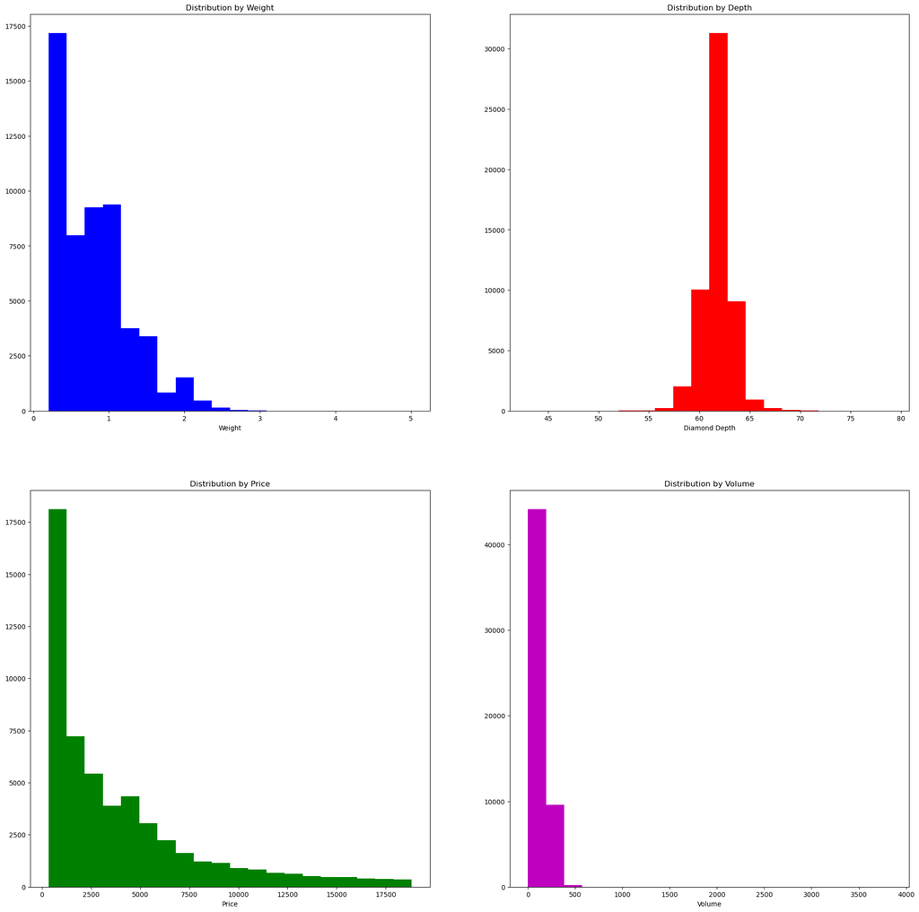

```python
# Let’s plot the data to know about the distribution.
import matplotlib.pyplot as plt

plt.figure(figsize=[24,24])

plt.subplot(221)
plt.hist(data_diam['carat'],bins=20,color='b')
plt.xlabel('Weight')
plt.title('Distribution by Weight')

plt.subplot(222)
plt.hist(data_diam['depth'],bins=20,color='r')
plt.xlabel('Diamond Depth')
plt.title('Distribution by Depth')

plt.subplot(223)
plt.hist(data_diam['price'],bins=20,color='g')
plt.xlabel('Price')
plt.title('Distribution by Price')

plt.subplot(224)
plt.hist(data_diam['volume'],bins=20,color='m')
plt.xlabel('Volume')
plt.title('Distribution by Volume')
```

### Fitting Ordinal regression

### Ordered probit model

```python
from statsmodels.miscmodels.ordinal_model import OrderedModel
mod_prob = OrderedModel(data_diam['cut'],
                        data_diam[['volume', 'price', 'carat']],
                        distr='probit')
```

```python
#fit and check the summary of the model using the following lines of codes
res_prob = mod_prob.fit(method='bfgs')
res_prob.summary()
```

```
Optimization terminated successfully.
         Current function value: 1.369122
         Iterations: 29
         Function evaluations: 35
         Gradient evaluations: 35
```

OrderedModel Results

| Dep. Variable: | cut | Log-Likelihood: | -73850. |
| --- | --- | --- | --- |
| Model: | OrderedModel | AIC: | 1.477e+05 |
| Method: | Maximum Likelihood | BIC: | 1.478e+05 |
| Date: | Sat, 14 Mar 2026 |  |  |
| Time: | 10:22:24 |  |  |
| No. Observations: | 53940 |  |  |
| Df Residuals: | 53933 |  |  |
| Df Model: | 7 |  |  |

|  | coef | std err | z | P>\|z\| | [0.025 | 0.975] |
| --- | --- | --- | --- | --- | --- | --- |
| volume | 0.0060 | 0.001 | 10.108 | 0.000 | 0.005 | 0.007 |
| price | 3.511e-05 | 3.01e-06 | 11.658 | 0.000 | 2.92e-05 | 4.1e-05 |
| carat | -1.1049 | 0.097 | -11.353 | 0.000 | -1.296 | -0.914 |
| Fair/Good | -1.8589 | 0.016 | -119.403 | 0.000 | -1.889 | -1.828 |
| Good/Ideal | -0.3292 | 0.014 | -24.056 | 0.000 | -0.356 | -0.302 |
| Ideal/Very Good | 0.2053 | 0.006 | 35.080 | 0.000 | 0.194 | 0.217 |
| Very Good/Premium | -0.4986 | 0.008 | -60.605 | 0.000 | -0.515 | -0.483 |

### Fitting Ordinal regression

### Ordered logit regression

```python
mod_prob = OrderedModel(data_diam['cut'],
                        data_diam[['volume', 'price', 'carat']],
                        distr='logit')

res_log = mod_prob.fit(method='bfgs')
res_log.summary()
```

```
Optimization terminated successfully.
         Current function value: 1.369215
         Iterations: 36
         Function evaluations: 42
         Gradient evaluations: 42
```

OrderedModel Results

| Dep. Variable: | cut | Log-Likelihood: | -73855. |
| --- | --- | --- | --- |
| Model: | OrderedModel | AIC: | 1.477e+05 |
| Method: | Maximum Likelihood | BIC: | 1.478e+05 |
| Date: | Sat, 14 Mar 2026 |  |  |
| Time: | 10:22:28 |  |  |
| No. Observations: | 53940 |  |  |
| Df Residuals: | 53933 |  |  |
| Df Model: | 7 |  |  |

|  | coef | std err | z | P>\|z\| | [0.025 | 0.975] |
| --- | --- | --- | --- | --- | --- | --- |
| volume | 0.0104 | 0.002 | 5.875 | 0.000 | 0.007 | 0.014 |
| price | 2.348e-05 | 5.31e-06 | 4.425 | 0.000 | 1.31e-05 | 3.39e-05 |
| carat | -1.5407 | 0.286 | -5.394 | 0.000 | -2.100 | -0.981 |
| Fair/Good | -3.2836 | 0.031 | -105.758 | 0.000 | -3.344 | -3.223 |
| Good/Ideal | 0.4038 | 0.015 | 27.062 | 0.000 | 0.375 | 0.433 |
| Ideal/Very Good | 0.7301 | 0.006 | 116.508 | 0.000 | 0.718 | 0.742 |
| Very Good/Premium | -0.0055 | 0.008 | -0.653 | 0.514 | -0.022 | 0.011 |

```python
#make the prediction from the model.
predicted = res_log.model.predict(
    res_log.params,
    exog=data_diam[['volume', 'price', 'carat']].to_numpy()
)

predicted
```

```
array([[0.03443606, 0.10308231, 0.42201809, 0.21495304, 0.2255105 ],
       [0.03468862, 0.10372996, 0.42298246, 0.21440769, 0.22419127],
       [0.03447851, 0.10319128, 0.42218114, 0.21486137, 0.2252877 ],
       ...,
       [0.03052062, 0.09285935, 0.40522189, 0.22335735, 0.2480408 ],
       [0.02973833, 0.0907751 , 0.40141256, 0.22500614, 0.25306787],
       [0.02970169, 0.09067712, 0.4012301 , 0.22508295, 0.25330815]])
```

source : https://analyticsindiamag.com/a-complete-tutorial-on-ordinal-regression-in-python/